# Project2

### AASD 4015 Advanced Mathematical Concepts for Deep Learning

### Project 2: MNIST Handwriting Classification

### The project is conducted by Cheuk Yin Li 101386432, Eman Elsefy 101428470, Shui Hei Yung 101409756

### The dataset is extracted from MNIST.

# Introduction

##### The project aims at classifing the image of handwriting words using convolutional neural network with hyperparameter tuning. The dataset consists of 60,000 training samples and 10,000 testing samples. There are 10 classes in total (0-9). Deep learning approach is used in this project.

```python
#!pip install d2l==1.0.0-beta0
```

[output not shown]

```python
#!nvidia-smi
```

```
Wed Mar 22 15:59:56 2023
+-----------------------------------------------------------------------------+
| NVIDIA-SMI 525.85.12    Driver Version: 525.85.12    CUDA Version: 12.0     |
|-------------------------------+----------------------+----------------------+
| GPU  Name        Persistence-M| Bus-Id        Disp.A | Volatile Uncorr. ECC |
| Fan  Temp  Perf  Pwr:Usage/Cap|         Memory-Usage | GPU-Util  Compute M. |
|                               |                      |               MIG M. |
|===============================+======================+======================|
|   0  Tesla T4            Off  | 00000000:00:04.0 Off |                    0 |
| N/A   40C    P0    24W /  70W |      0MiB / 15360MiB |      0%      Default |
|                               |                      |                  N/A |
+-------------------------------+----------------------+----------------------+

+-----------------------------------------------------------------------------+
| Processes:                                                                  |
|  GPU   GI   CI        PID   Type   Process name                  GPU Memory |
|        ID   ID                                                   Usage      |
|=============================================================================|
|  No running processes found                                                 |
+-----------------------------------------------------------------------------+
```

```python
import torch
torch.cuda.is_available()
```

```
True
```

Import Library

```python
import tensorflow as tf
from tensorflow import keras
import matplotlib.pyplot as plt
%matplotlib inline
import numpy as np
from keras.models import Sequential
from keras.layers import Dense, Dropout, Flatten
from keras.layers import Conv2D, MaxPooling2D
from keras.utils.vis_utils import plot_model
from keras import backend as K
import torch as t
import pandas as pd
import seaborn as sns
from sklearn.decomposition import PCA
from sklearn.metrics import recall_score
```

Import dataset

```python
(x_train, y_train), (x_test, y_test) = keras.datasets.mnist.load_data()
```

```
Downloading data from https://storage.googleapis.com/tensorflow/tf-keras-datasets/mnist.npz
```

Data exploration

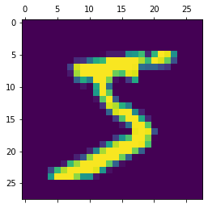

```python
#Display the sample image
plt.matshow(x_train[0])
```

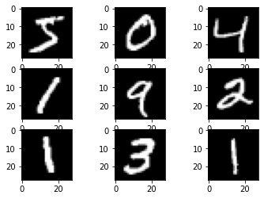

```python
# Showing sample images in grayscale
for i in range(9):
 plt.subplot(330 + 1 + i)
 plt.imshow(x_train[i], cmap=plt.get_cmap('gray'))
```

```python
train_df = pd.DataFrame({'image': [x for x in x_train], 'label': y_train})
test_df = pd.DataFrame({'image': [x for x in x_test], 'label': y_test})
```

```python
class_counts = pd.DataFrame({"label": train_df['label'].value_counts().index, "count": train_df['label'].value_counts()})
```

```python
class_counts = class_counts.sort_values("label")
```

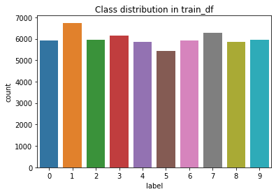

```python
# The class distribution is a nearly equal distributed which means the biases of data is relatively low.
sns.barplot(class_counts, x="label", y="count")
plt.title("Class distribution in train_df")
plt.show()
```

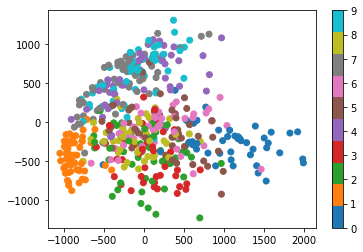

```python
#By coloring the points based on their corresponding labels, we can visualize how the different classes are distributed in this space, and whether there are any clear patterns or clusters that separate them from each other.
idx = np.random.randint(x_train.shape[0], size=500)
x_train_sample = x_train[idx, :]
y_train_sample = y_train[idx]

# Fit PCA model to the data
pca = PCA(n_components=2)
x_train_pca = pca.fit_transform(x_train_sample.reshape(x_train_sample.shape[0], -1))

# Plot the scatterplot
plt.scatter(x_train_pca[:, 0], x_train_pca[:, 1], c=y_train[idx], cmap='tab10')
plt.colorbar()
plt.show()
```

Data Preprocessing

```python
# sample only 20k images for training
idx = np.random.randint(x_train.shape[0], size=20000)
x_train = x_train[idx, :]
y_train = y_train[idx]
print('Shape of x_train: ',x_train.shape)
print('Shape of y_train: ',y_train.shape)

# specify input dimensions of each image
img_rows, img_cols = 28, 28
input_shape = (img_rows, img_cols, 1)

batch_size = 128
num_classes = 10

epochs = 20
# reshape x_train and x_test
x_train = x_train.reshape(x_train.shape[0], img_rows, img_cols, 1)
x_test = x_test.reshape(x_test.shape[0], img_rows, img_cols, 1)
print('Reshape of x_train: ',x_train.shape)
print('Reshape of x_test: ',x_test.shape)

# convert class labels from digits to one-hot encoded vectors
y_train = keras.utils.to_categorical(y_train, num_classes)
y_test = keras.utils.to_categorical(y_test, num_classes)
print('Shape of y_train: ',y_train.shape)

# convert int to float
x_train = x_train.astype('float32')
x_test = x_test.astype('float32')

# normalise
x_train /= 255
x_test /= 255
```

```
Shape of x_train:  (20000, 28, 28)
Shape of y_train:  (20000,)
Reshape of x_train:  (20000, 28, 28, 1)
Reshape of x_test:  (10000, 28, 28, 1)
Shape of y_train:  (20000, 10)
```

Model 1: Baseline Model

This is a basic CNN model for image classification that consists of three layers: a convolutional layer, a fully connected layer, and a softmax output layer. The convolutional layer contains 32 filters of size 3x3 and applies the relu activation function to each output. The fully connected layer contains 128 neurons and applies the relu activation function as well as a dropout regularization with rate of 0.5. The final softmax layer is used to output the class probabilities for the input image. The model is compiled with categorical cross-entropy loss and optimized using the Adam optimizer.

```python
model = Sequential()

# first conv layer
model.add(Conv2D(32, kernel_size=(3, 3),
                 activation='relu',
                 input_shape=input_shape))



# flatten and put a fully connected layer
model.add(Flatten())
model.add(Dense(128, activation='relu'))
model.add(Dropout(0.5))

# softmax layer
model.add(Dense(num_classes, activation='softmax'))

model.summary()

# usual cross entropy loss
model.compile(loss=keras.losses.categorical_crossentropy,
              optimizer='adam',
              metrics=['accuracy'])

# fit the model
fit_model = model.fit(x_train, y_train,
          batch_size=batch_size,
          epochs=epochs,
          verbose=1,
          validation_data=(x_test, y_test))

# Save the model
model.save('BaseModel.h5')

# evaluate the model on test data
model.evaluate(x_test, y_test)
```

```
Model: "sequential"
_________________________________________________________________
 Layer (type)                Output Shape              Param #
=================================================================
 conv2d (Conv2D)             (None, 26, 26, 32)        320

 flatten (Flatten)           (None, 21632)             0

 dense (Dense)               (None, 128)               2769024

 dropout (Dropout)           (None, 128)               0

 dense_1 (Dense)             (None, 10)                1290

=================================================================
Total params: 2,770,634
Trainable params: 2,770,634
Non-trainable params: 0
_________________________________________________________________
```

```
[0.08885139971971512, 0.9804999828338623]
```

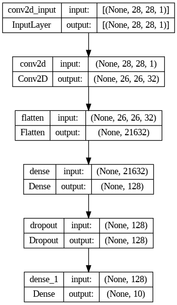

```python
plot_model(model, to_file='model_plot.png', show_shapes=True, show_layer_names=True)
```

```python
# evaluate the model on test data
test_loss, test_accuracy = model.evaluate(x_test, y_test, verbose=0)

# print the test loss and accuracy
print('Test loss:', test_loss)
print('Test accuracy:', test_accuracy)
```

```
Test loss: 0.08885139971971512
Test accuracy: 0.9804999828338623
```

##### The base model performs quite well in terms of high accuracy rate and low value in loss.

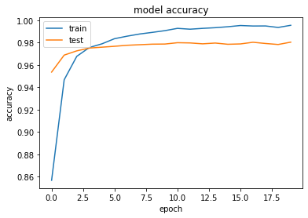

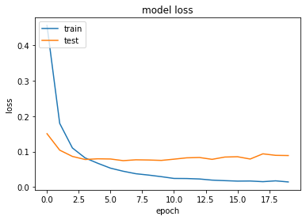

```python
plt.plot(fit_model.history['accuracy'])
plt.plot(fit_model.history['val_accuracy'])

plt.title('model accuracy')
plt.ylabel('accuracy')
plt.xlabel('epoch')
plt.legend(['train','test'], loc='upper left')
plt.show()

plt.plot(fit_model.history['loss'])
plt.plot(fit_model.history['val_loss'])

plt.title('model loss')
plt.ylabel('loss')
plt.xlabel('epoch')
plt.legend(['train','test'], loc='upper left')
plt.show()
```

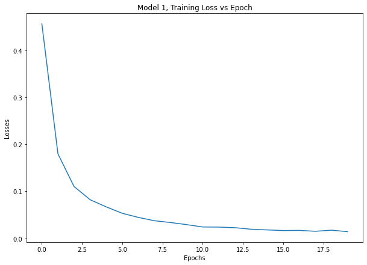

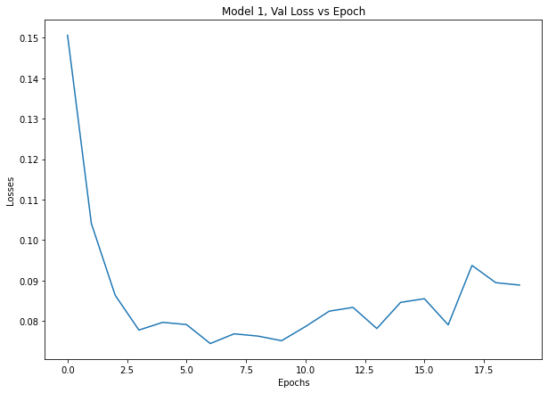

```python
plt.figure(figsize =(10,7))
plt.plot(fit_model.history["loss"])
plt.xlabel("Epochs")
plt.ylabel("Losses")
plt.title("Model 1, Training Loss vs Epoch")
plt.show()

plt.figure(figsize =(10,7))
plt.plot(fit_model.history["val_loss"])
plt.xlabel("Epochs")
plt.ylabel("Losses")
plt.title("Model 1, Val Loss vs Epoch")
plt.show()
```

Model 2

The model has two convolutional layers with 32 and 64 filters respectively, each with a kernel size of 3x3 and a sigmoid activation function. The second convolutional layer is followed by a max pooling layer with a pool size of 2x2 and a dropout layer with a rate of 0.25.

After the convolutional layers, the output is flattened and passed to a fully connected layer with 128 neurons and a sigmoid activation function. This layer is followed by another dropout layer with a rate of 0.5, and finally a softmax layer with 10 neurons and a softmax activation function.

```python
# Add second conv layer & activation using sigmoid
model2 = Sequential()

input_shape = (28,28,1)
# First conv layer
model2.add(Conv2D(32, kernel_size=(3, 3),
                 activation='sigmoid',
                 input_shape=input_shape))

# Second conv layer
model2.add(Conv2D(64, kernel_size=(3, 3),
                 activation='sigmoid'))
model2.add(MaxPooling2D(pool_size=(2, 2)))
model2.add(Dropout(0.25))

# Flatten and put a fully connected layer
model2.add(Flatten())
model2.add(Dense(128, activation='sigmoid')) # Fully connected
model2.add(Dropout(0.5))

# Softmax layer
model2.add(Dense(10, activation='softmax'))

model2.summary()

# Usual cross entropy loss
model2.compile(loss=keras.losses.categorical_crossentropy,
              optimizer='adam',
              metrics=['accuracy'])

# Fit the model
fit_model2 = model2.fit(x_train, y_train,
          batch_size=batch_size,
          epochs=epochs,
          verbose=1,
          validation_data=(x_test, y_test))

# Save the model
model2.save('Model2.h5')

# Evaluate the model on test data
model2.evaluate(x_test, y_test)
```

```
Model: "sequential_1"
_________________________________________________________________
 Layer (type)                Output Shape              Param #
=================================================================
 conv2d_1 (Conv2D)           (None, 26, 26, 32)        320

 conv2d_2 (Conv2D)           (None, 24, 24, 64)        18496

 max_pooling2d (MaxPooling2D  (None, 12, 12, 64)       0
 )

 dropout_1 (Dropout)         (None, 12, 12, 64)        0

 flatten_1 (Flatten)         (None, 9216)              0

 dense_2 (Dense)             (None, 128)               1179776

 dropout_2 (Dropout)         (None, 128)               0

 dense_3 (Dense)             (None, 10)                1290

=================================================================
Total params: 1,199,882
Trainable params: 1,199,882
Non-trainable params: 0
_________________________________________________________________
```

```
[0.06799197942018509, 0.9786999821662903]
```

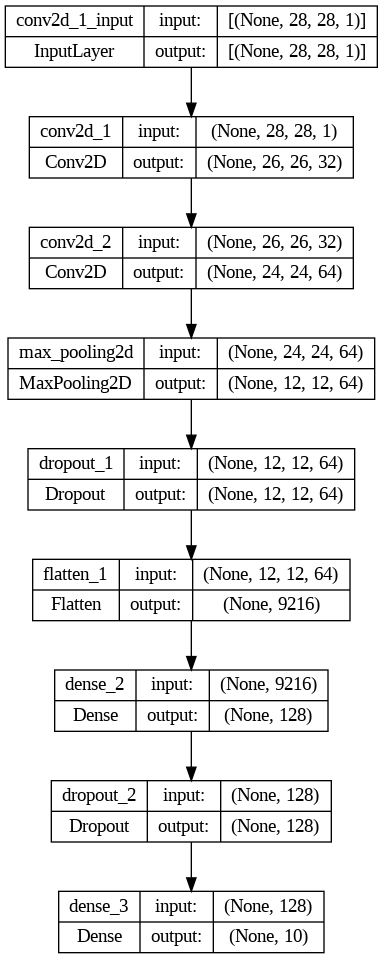

```python
plot_model(model2, to_file='model_plot.png', show_shapes=True, show_layer_names=True)
```

```python
# evaluate the model on test data
test_loss, test_accuracy = model2.evaluate(x_test, y_test, verbose=0)

# print the test loss and accuracy
print('Test loss:', test_loss)
print('Test accuracy:', test_accuracy)
```

```
Test loss: 0.06799197942018509
Test accuracy: 0.9786999821662903
```

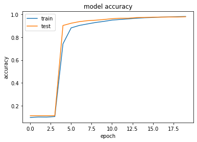

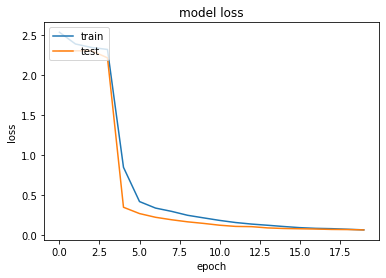

```python
plt.plot(fit_model2.history['accuracy'])
plt.plot(fit_model2.history['val_accuracy'])

plt.title('model accuracy')
plt.ylabel('accuracy')
plt.xlabel('epoch')
plt.legend(['train','test'], loc='upper left')
plt.show()

plt.plot(fit_model2.history['loss'])
plt.plot(fit_model2.history['val_loss'])

plt.title('model loss')
plt.ylabel('loss')
plt.xlabel('epoch')
plt.legend(['train','test'], loc='upper left')
plt.show()
```

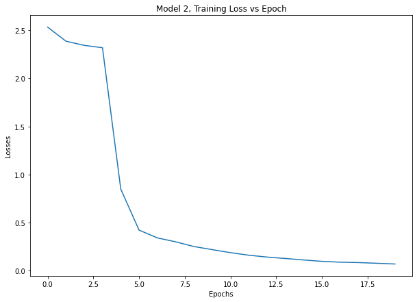

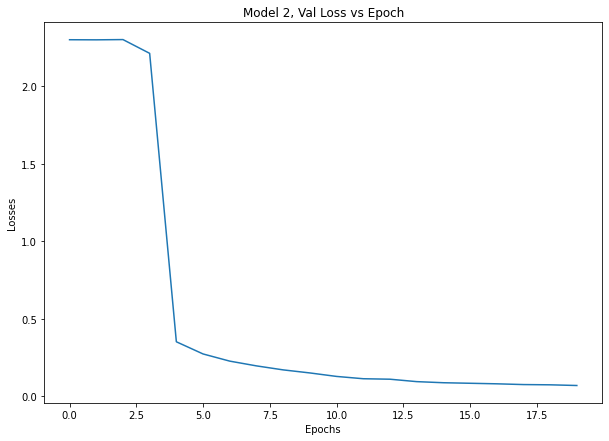

```python
plt.figure(figsize =(10,7))
plt.plot(fit_model2.history["loss"])
plt.xlabel("Epochs")
plt.ylabel("Losses")
plt.title("Model 2, Training Loss vs Epoch")
plt.show()

plt.figure(figsize =(10,7))
plt.plot(fit_model2.history["val_loss"])
plt.xlabel("Epochs")
plt.ylabel("Losses")
plt.title("Model 2, Val Loss vs Epoch")
plt.show()
```

Model 3

The first convolutional layer uses a filter size of 4x4, a stride of (2,1), and applies the tanh activation function. The second convolutional layer uses a filter size of 4x4 and the tanh activation function, followed by a max pooling layer with a pool size of 2x2, and a dropout regularization with a rate of 0.25. The output of these layers is then flattened and passed to a fully connected layer with 128 neurons and a tanh activation function. Another dropout layer with a rate of 0.5 is added before the final softmax layer, which outputs class probabilities for the input image. The model is compiled with categorical cross-entropy loss and optimized using the Adam optimizer.

```python
#add strides & activation using tanh
model3 = Sequential()

# a keras convolutional layer = Conv2D

# first conv layer
model3.add(Conv2D(32, kernel_size=(4, 4),
                 activation='tanh',
                 input_shape=input_shape,
                 strides=(2,1)))
# second conv layer
model3.add(Conv2D(64, kernel_size=(4, 4),
                 activation='tanh'))
model3.add(MaxPooling2D(pool_size=(2, 2)))
model3.add(Dropout(0.25))

# flatten and put a fully connected layer
model3.add(Flatten())
model3.add(Dense(128, activation='tanh'))
model3.add(Dropout(0.5))

# softmax layer
model3.add(Dense(num_classes, activation='softmax'))

model3.summary()

# usual cross entropy loss
model3.compile(loss=keras.losses.categorical_crossentropy,
              optimizer='adam',
              metrics=['accuracy'])

# fit the model
fit_model3 = model3.fit(x_train, y_train,
          batch_size=batch_size,
          epochs=epochs,
          verbose=1,
          validation_data=(x_test, y_test))

# Save the model
model3.save('Model3.h5')

# evaluate the model on test data
model3.evaluate(x_test, y_test)
```

```
Model: "sequential_2"
_________________________________________________________________
 Layer (type)                Output Shape              Param #
=================================================================
 conv2d_3 (Conv2D)           (None, 13, 25, 32)        544

 conv2d_4 (Conv2D)           (None, 10, 22, 64)        32832

 max_pooling2d_1 (MaxPooling  (None, 5, 11, 64)        0
 2D)

 dropout_3 (Dropout)         (None, 5, 11, 64)         0

 flatten_2 (Flatten)         (None, 3520)              0

 dense_4 (Dense)             (None, 128)               450688

 dropout_4 (Dropout)         (None, 128)               0

 dense_5 (Dense)             (None, 10)                1290

=================================================================
Total params: 485,354
Trainable params: 485,354
Non-trainable params: 0
_________________________________________________________________
```

```
[0.051677025854587555, 0.9840999841690063]
```

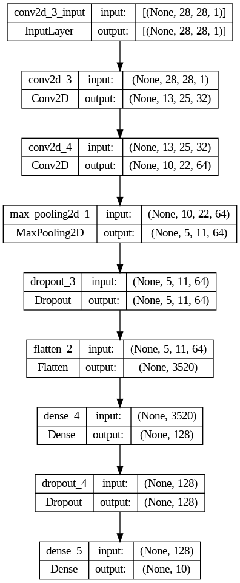

```python
plot_model(model3, to_file='model_plot.png', show_shapes=True, show_layer_names=True)
```

```python
# evaluate the model on test data
test_loss, test_accuracy = model3.evaluate(x_test, y_test, verbose=0)

# print the test loss and accuracy
print('Test loss:', test_loss)
print('Test accuracy:', test_accuracy)
```

```
Test loss: 0.051677025854587555
Test accuracy: 0.9840999841690063
```

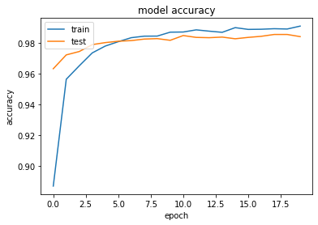

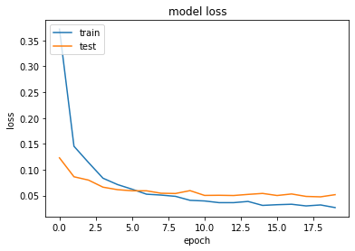

```python
plt.plot(fit_model3.history['accuracy'])
plt.plot(fit_model3.history['val_accuracy'])

plt.title('model accuracy')
plt.ylabel('accuracy')
plt.xlabel('epoch')
plt.legend(['train','test'], loc='upper left')
plt.show()

plt.plot(fit_model3.history['loss'])
plt.plot(fit_model3.history['val_loss'])

plt.title('model loss')
plt.ylabel('loss')
plt.xlabel('epoch')
plt.legend(['train','test'], loc='upper left')
plt.show()
```

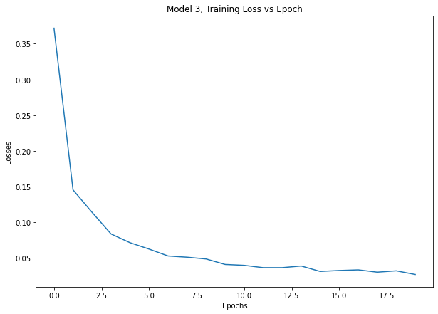

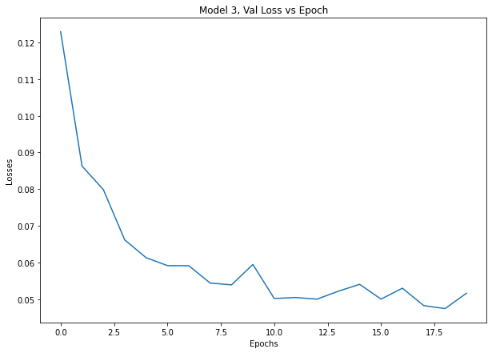

```python
plt.figure(figsize =(10,7))
plt.plot(fit_model3.history["loss"])
plt.xlabel("Epochs")
plt.ylabel("Losses")
plt.title("Model 3, Training Loss vs Epoch")
plt.show()

plt.figure(figsize =(10,7))
plt.plot(fit_model3.history["val_loss"])
plt.xlabel("Epochs")
plt.ylabel("Losses")
plt.title("Model 3, Val Loss vs Epoch")
plt.show()
```

Model 4

The first convolutional layer uses a filter size of 4x4, a stride of (2,1), tanh activation function, and same padding. The second convolutional layer uses a filter size of 4x4 and the tanh activation function, followed by a max pooling layer with a pool size of 2x2, and a dropout regularization with a rate of 0.25. The output of these layers is then flattened and passed to a fully connected layer with 128 neurons and a tanh activation function. Another dropout layer with a rate of 0.5 is added before the final softmax layer, which outputs class probabilities for the input image. The model is compiled with categorical cross-entropy loss and optimized using the Adam optimizer.

```python
#add padding
model4 = Sequential()

# first conv layer
model4.add(Conv2D(32, kernel_size=(4, 4),
                 activation='tanh',
                 input_shape=input_shape,
                strides=(2,1) , padding='same')) # input shape = (img_rows, img_cols, 1)
# second conv layer
model4.add(Conv2D(64, kernel_size=(4, 4),
                 activation='tanh'))
model4.add(MaxPooling2D(pool_size=(2, 2)))
model4.add(Dropout(0.25))

# flatten and put a fully connected layer
model4.add(Flatten())
model4.add(Dense(128, activation='tanh'))
model4.add(Dropout(0.5))

# softmax layer
model4.add(Dense(num_classes, activation='softmax'))

model4.summary()

# usual cross entropy loss
model4.compile(loss=keras.losses.categorical_crossentropy,
              optimizer='adam',
              metrics=['accuracy'])

# fit the model
fit_model4 = model4.fit(x_train, y_train,
          batch_size=batch_size,
          epochs=epochs,
          verbose=1,
          validation_data=(x_test, y_test))

# evaluate the model on test data
model4.evaluate(x_test, y_test)
```

```
Model: "sequential_3"
_________________________________________________________________
 Layer (type)                Output Shape              Param #
=================================================================
 conv2d_5 (Conv2D)           (None, 14, 28, 32)        544

 conv2d_6 (Conv2D)           (None, 11, 25, 64)        32832

 max_pooling2d_2 (MaxPooling  (None, 5, 12, 64)        0
 2D)

 dropout_5 (Dropout)         (None, 5, 12, 64)         0

 flatten_3 (Flatten)         (None, 3840)              0

 dense_6 (Dense)             (None, 128)               491648

 dropout_6 (Dropout)         (None, 128)               0

 dense_7 (Dense)             (None, 10)                1290

=================================================================
Total params: 526,314
Trainable params: 526,314
Non-trainable params: 0
_________________________________________________________________
```

```
[0.05184290185570717, 0.9847000241279602]
```

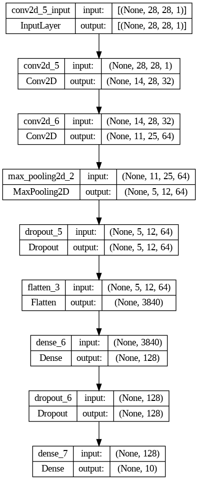

```python
plot_model(model4, to_file='model_plot4.png', show_shapes=True, show_layer_names=True)
```

```python
# evaluate the model on test data
test_loss, test_accuracy = model4.evaluate(x_test, y_test, verbose=0)

# print the test loss and accuracy
print('Test loss:', test_loss)
print('Test accuracy:', test_accuracy)
```

```
Test loss: 0.05184290185570717
Test accuracy: 0.9847000241279602
```

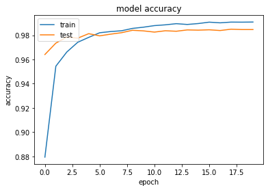

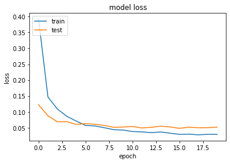

```python
plt.plot(fit_model4.history['accuracy'])
plt.plot(fit_model4.history['val_accuracy'])

plt.title('model accuracy')
plt.ylabel('accuracy')
plt.xlabel('epoch')
plt.legend(['train','test'], loc='upper left')
plt.show()

plt.plot(fit_model4.history['loss'])
plt.plot(fit_model4.history['val_loss'])

plt.title('model loss')
plt.ylabel('loss')
plt.xlabel('epoch')
plt.legend(['train','test'], loc='upper left')
plt.show()
```

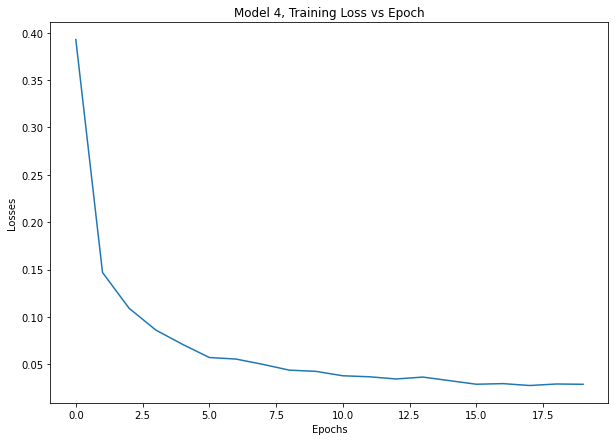

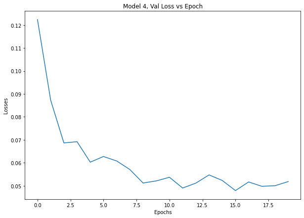

```python
plt.figure(figsize =(10,7))
plt.plot(fit_model4.history["loss"])
plt.xlabel("Epochs")
plt.ylabel("Losses")
plt.title("Model 4, Training Loss vs Epoch")
plt.show()

plt.figure(figsize =(10,7))
plt.plot(fit_model4.history["val_loss"])
plt.xlabel("Epochs")
plt.ylabel("Losses")
plt.title("Model 4, Val Loss vs Epoch")
plt.show()
```